# Final Project

## Model Selection and Performance

```r
best_metrics=bind_rows(svm_best,class_tree_best,rf_best,boost_best)
best_metrics=best_metrics %>% add_column('model' = c("SVM","Pruned Decision Tree","Random Forest","Boosted Tree"),'roc_auc' = c(0.7154, 0.7583, 0.7803,0.7816))
best_metrics[,c("model",".config","cost_complexity","mtry","trees","min_n","roc_auc")]
```

[output not shown]

After selecting our the best model, we want to test the accuracy of model on the testing data set.

```r
best_model <- select_best(rf_tune_res, metric = "roc_auc")

final <- finalize_workflow(rf_wf, best_model)

final_fit <- fit(final, data = train)

predicted_data <- augment(final_fit, new_data = test) %>%
  select(quality, starts_with(".pred"))
```

```r
predicted_data %>% roc_auc(quality, .pred_3:.pred_8)
```

| .metric | .estimator | .estimate |
| --- | --- | --- |
| roc_auc | hand_till | 0.6957 |

Plotting the ROC curves of different quality.

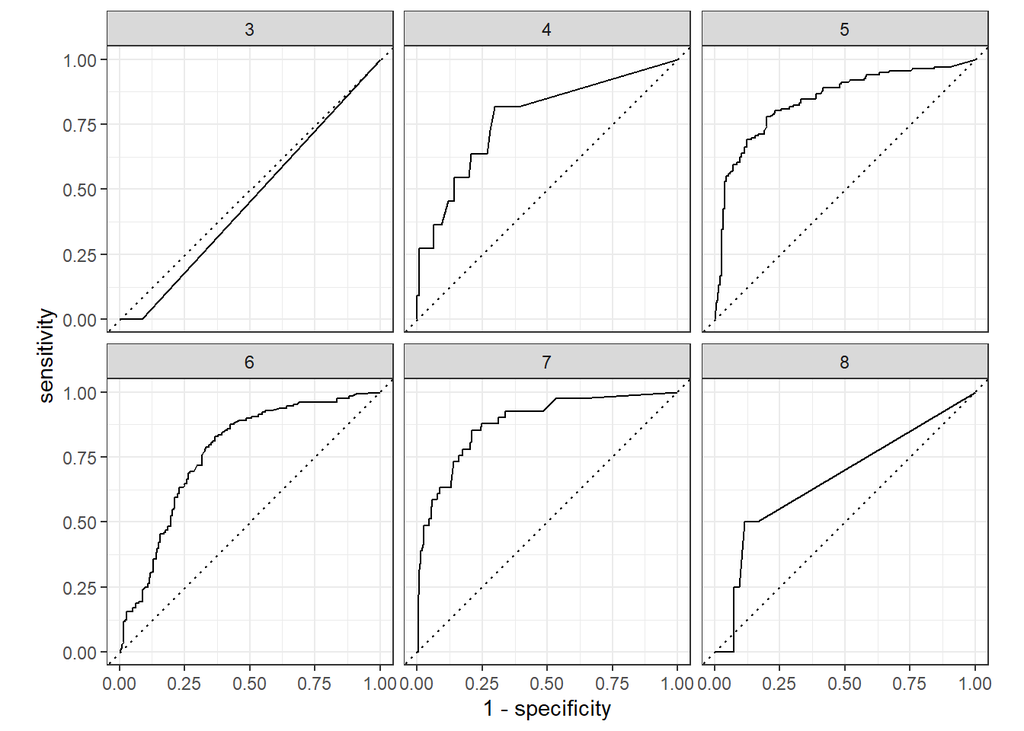

```r
predicted_data %>% roc_curve(quality, .pred_3:.pred_8) %>%
  autoplot()
```

Heat map of the confusion matrix. We notice that quality 5 and quality 6 have the most correct predictions, which is not surprising, because quality 5 and quality 6 have the most wine.

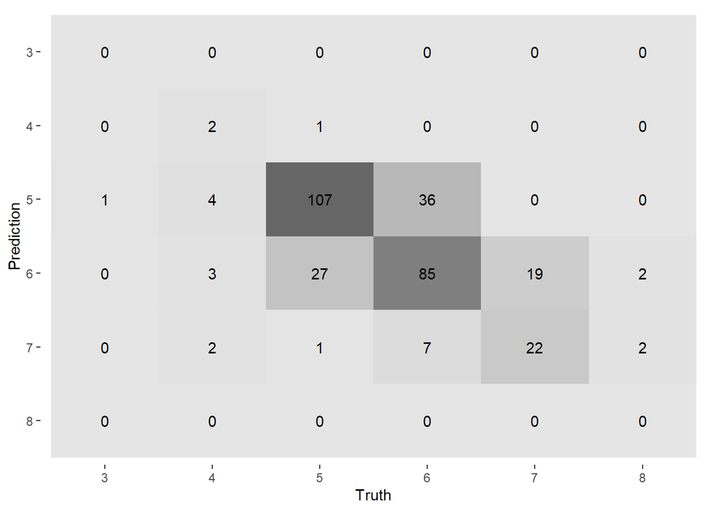

```r
predicted_data %>%
  conf_mat(truth = quality, estimate = .pred_class) %>%
  autoplot(type = "heatmap")
```

## Conclusion

The analysis above gives us an idea about how different physicochemical factors of wine can affect the its quality.

Further research on this model can be done if more observations or more variables are introduced. While there is still much improvement to made to our model, it performance is great to me.